# tutorial30-page-history

## Tutorial 30: MediaWiki Page History

Here, we return to our study of the MediaWiki API. This will be a useful review of how to grab and parse data, both are key steps in doing work in data science. Specifically, we will see how to grab and parse the history of a wikipedia page.

Start by loading some useful modules:

```python
import json
import os
from os.path import join
import re
import requests

import wiki
import iplot
import matplotlib.pyplot as plt
```

I am going to demonstrate at first using the Wikipedia page for coffee. You'll be able to look at other pages later in the tutorial. To start, let's grab the page JSON file (either from disk or downloaded through the functions provided in `wiki.py`). I'll also print out the keys in the returned dictionary object.

```python
page_json = wiki.get_wiki_json("Coffee")
page_json.keys()
```

```
dict_keys(['title', 'pageid', 'revid', 'redirects', 'text', 'langlinks', 'categories', 'links', 'templates', 'images', 'externallinks', 'sections', 'parsewarnings', 'displaytitle', 'iwlinks', 'properties'])
```

We have not done anything with the 'revid', but this will be key for our work today. The 'revid' is a unique key that describes a particular version of a page. It is unique *on it's own*; you do not need to combine it with the 'pageid' (I found this confusing in the MediaWiki documentation).

### Query API

In order to get previous revision ids for a given page, we need to use the 'query' API. Last time, and throughout the semester so far, we have been only using the 'parse' functionality of the MediaWiki API. Let's see how the query API works. Recall that we need a base API URL that the query is sent to. This remains unchanged from tutorial 8:

```python
lang = 'en'
base_api_url = 'https://' + lang + '.wikipedia.org/w/api.php?'
base_api_url
```

```
'https://en.wikipedia.org/w/api.php?'
```

Now, we produce a query by providing variable keys separated by the amperstand (&) symbol. For the query API we need to specify the following:

- `action=query` to describe the action that we want to take
- `format=json` to let the API know we want data returned as JSON objects
- `prop=revisions` to tell the API that we want to see the page revisions
- `rvprop=ids|flags|timestamp|comment|user` indicate what data to return about the revision
- `rvstartid=######` to indicate the revision we want to start at, with the proper revid filled in for the `########`

Start by extracting the revid for the Coffee page:

```python
pageid = page_json['pageid']
pageid
```

```
604727
```

```python
revid = page_json['revid']
revid
```

```
865835930
```

And then construct the API query:

```python
api_query = base_api_url + "action=query&" + "format=json&" + \
            "prop=revisions&" + "rvprop=ids|flags|timestamp|comment|user&" \
            "pageids={0:d}&".format(pageid) + \
            "rvstartid={0:d}&".format(revid)
api_query
```

```
'https://en.wikipedia.org/w/api.php?action=query&format=json&prop=revisions&rvprop=ids|flags|timestamp|comment|user&pageids=604727&rvstartid=865835930&'
```

Finally, we can call the API and have the page data returned to us. Take a few minutes to look at the output before moving on the next section.

```python
r = requests.get(api_query)
page_data = r.json()
page_data
```

```
{'continue': {'rvcontinue': '20181003154447|862314871', 'continue': '||'},
 'query': {'pages': {'604727': {'pageid': 604727,
    'ns': 0,
    'title': 'Coffee',
    'revisions': [{'revid': 865835930,
      'parentid': 865835769,
      'user': 'The Madras',
      'timestamp': '2018-10-26T13:55:56Z',
      'comment': '/* Coffeehouses */'},
     {'revid': 865835769,
      'parentid': 865834651,
      'user': 'The Madras',
      'timestamp': '2018-10-26T13:54:31Z',
      'comment': '/* Coffeehouses */'},
     {'revid': 865834651,
      'parentid': 864501853,
      'minor': '',
      'user': 'The Madras',
      'timestamp': '2018-10-26T13:44:33Z',
      'comment': 'no need for those pictures in the lead'},
     {'revid': 864501853,
      'parentid': 864501313,
      'user': 'Heroeswithmetaphors',
      'timestamp': '2018-10-17T17:07:50Z',
      'comment': '/* Caffeine content */links'},
     {'revid': 864501313,
      'parentid': 864501192,
      'user': 'Heroeswithmetaphors',
      'timestamp': '2018-10-17T17:03:25Z',
      'comment': "/* Parkinson's disease */link"},
     {'revid': 864501192,
      'parentid': 863262382,
      'user': 'Heroeswithmetaphors',
      'timestamp': '2018-10-17T17:02:20Z',
      'comment': '/* Mortality */links'},
     {'revid': 863262382,
      'parentid': 863213758,
      'user': 'Funfactsandwheretofindthem',
      'timestamp': '2018-10-09T18:06:40Z',
      'comment': "/* Coffeehouses */ Updated Starbucks' outlet numbers from 2010 date"},
     {'revid': 863213758,
      'parentid': 863088071,
      'minor': '',
      'user': 'Leningrad',
      'timestamp': '2018-10-09T12:08:40Z',
      'comment': ''},
     {'revid': 863088071,
      'parentid': 863082281,
      'user': 'Zefr',
      'timestamp': '2018-10-08T17:00:11Z',
      'comment': '/* Method of action */ add more focused review using [[WP:UCB|Citation bot]]'},
     {'revid': 863082281,
      'parentid': 862314871,
      'user': 'Supersarah1121',
      'timestamp': '2018-10-08T16:13:31Z',
      'comment': 'Medical Citation Added'}]}}}}
```

What information is shown about revision? What information does the parameter 'parentid' give you about the revision? How many revisions are returned here?

**Answer**:

### Parsing page dates

I want you to try writing some code again. Cycle through the output of `page_data` to produce a python list named `rev_years` that gives the year of each revision. Note: you might start by storing the entire time stamp and then modify the code to store just the year. Second note: You don't need to be too clever to get the year from the time stamp, just take the first four characters in the string.

```python
revisions = page_data['query']['pages']['604727']['revisions']
len(revisions)
```

```
10
```

```python
rev_years = []

for rev in revisions:
    rev_years.append(rev['timestamp'][:4])

rev_years
```

```
['2018',
 '2018',
 '2018',
 '2018',
 '2018',
 '2018',
 '2018',
 '2018',
 '2018',
 '2018']
```

Once you have created the list `rev_years`, run the following to show how many revisions there are in each year.

```python
import collections

collections.Counter(rev_years)
```

```
Counter({'2018': 10})
```

The output likely won't be too interesting yet because you only have the first 10 revisions of the page. Let's see how to rectify that now.

### Increasing the page limit

By default, MediaWiki returns only the last 10 revisions. We can fetch up to 500 revisions by adding the parameter `rvlimit=max` to the query. Modify the variable `api_query` and fetch the modifyied data. I suggest NOT printing out the results of `page_data` because there will be a lot of them!

```python
api_query = base_api_url + "action=query&" + "format=json&" + \
            "prop=revisions&" + "rvprop=ids|flags|timestamp|comment|user&" \
            "rvlimit=max&" + \
            "pageids={0:d}&".format(pageid) + \
            "rvstartid={0:d}&".format(revid)
r = requests.get(api_query)
page_data = r.json()

revisions = page_data['query']['pages']['604727']['revisions']
```

Now, copy the code you had above to find the distribution of years for the first 500 revisions.

```python
rev_years = []

for rev in revisions:
    rev_years.append(rev['timestamp'][:4])

collections.Counter(rev_years)
```

```
Counter({'2018': 112, '2017': 386, '2016': 2})
```

You should see about 112 revisions for 2018, 386 for 2017, and just 2 for 2016. This is a bit more interesting, but still not the whole story because even the maximum query returns just 500 pages.

### Continuing the query

In order to get more results from the API we must place another query request. This is similar to seeing the "next page" of results on a site such as Google or Amazon when searching for a webpage or product. The idea here is common to many API's such as the ones used by Google, Twitter, and Facebook.

Notice that the variable `page_data` contains an element named `continue`:

```python
page_data['continue']
```

```
{'rvcontinue': '20161214161444|754802248', 'continue': '||'}
```

Create a variable `api_query_continue` that adds the parameter `rvcontinue=######` with the `#####` filled in from the above value to the variable `api_query`.

```python
api_query_continue = api_query + "rvcontinue=" + page_data['continue']['rvcontinue']
```

Next, call this query and load the data into the variable `page_data`.

```python
r = requests.get(api_query_continue)
page_data = r.json()
```

And now see the distribution of page years in this new chunk of data:

```python
rev_years = []

for rev in page_data['query']['pages'][str(pageid)]['revisions']:
    rev_years.append(rev['timestamp'][:4])

collections.Counter(rev_years)
```

```
Counter({'2016': 322, '2015': 178})
```

You should see about 322 revisions in 2016 and another 178 in 2015.

### Getting all of the pages

We still do not have all of the Coffee pages, just the next 500 of them. In order to get all of the pages we have to cycle through these continue statements until we reach the end of the pages. Let's write the code to handle this now. Rather than just grabbing the years, we will construct a list of all the information about each revision.

I've written the function here for you to generate the list of revisions, but you should be able to understand what is going on in all of the code. It spits out the progress of the API by showing the number of revisions grabbed as well as indicating what the last timestamp grabbed was.

```python
def wiki_page_revisions(page_title):
    page_json = wiki.get_wiki_json(page_title)
    pageid = page_json['pageid']
    revid = page_json['revid']

    api_query = base_api_url + "action=query&" + "format=json&" + \
                "prop=revisions&" + "rvprop=ids|flags|timestamp|comment|user&" \
                "rvlimit=max&" + \
                "pageids={0:d}&".format(pageid) + \
                "rvstartid={0:d}&".format(revid)
    r = requests.get(api_query)
    page_data = r.json()

    rev_data = page_data['query']['pages'][str(pageid)]['revisions']

    while 'continue' in page_data:
        api_query_continue = api_query + \
                             "rvcontinue={0:s}&".format(page_data['continue']['rvcontinue'])
        r = requests.get(api_query_continue)
        page_data = r.json()
        rev_data += page_data['query']['pages'][str(pageid)]['revisions']
        msg = "Loaded {0:d} revisions, through {1:s}"
        print(msg.format(len(rev_data), rev_data[-1]['timestamp']))

    return rev_data
```

```python
rev_data = wiki_page_revisions("Coffee")
```

```
Loaded 1000 revisions, through 2015-10-06T08:23:46Z
Loaded 1500 revisions, through 2014-09-14T21:47:07Z
Loaded 2000 revisions, through 2013-10-27T19:56:47Z
Loaded 2500 revisions, through 2013-02-05T18:42:36Z
Loaded 3000 revisions, through 2012-03-22T05:58:50Z
Loaded 3500 revisions, through 2011-05-27T18:39:36Z
Loaded 4000 revisions, through 2010-09-17T23:47:21Z
Loaded 4500 revisions, through 2010-02-13T10:47:58Z
Loaded 5000 revisions, through 2009-12-04T23:59:54Z
Loaded 5500 revisions, through 2009-05-16T00:31:27Z
Loaded 6000 revisions, through 2008-12-06T00:40:05Z
Loaded 6500 revisions, through 2008-05-17T16:42:47Z
Loaded 7000 revisions, through 2007-12-19T01:21:52Z
Loaded 7500 revisions, through 2007-09-17T14:02:50Z
Loaded 8000 revisions, through 2007-06-12T21:59:14Z
Loaded 8500 revisions, through 2007-03-13T18:05:46Z
Loaded 9000 revisions, through 2006-11-21T17:23:22Z
Loaded 9500 revisions, through 2006-08-27T12:38:01Z
Loaded 10000 revisions, through 2006-04-11T18:00:27Z
Loaded 10500 revisions, through 2005-12-15T11:29:51Z
Loaded 11000 revisions, through 2005-05-09T23:33:14Z
Loaded 11236 revisions, through 2004-04-18T21:41:42Z
```

Just looking at the message output, how many revisions have been made to the Coffee page and when was the page first created?

**Answer**:

Modify your code you used above to grab the list `rev_years` from the list `rev_data`.

```python
 rev_years = []

for rev in rev_data:
    rev_years.append(rev['timestamp'][:4])

collections.Counter(rev_years)
```

```
Counter({'2018': 112,
         '2017': 386,
         '2016': 324,
         '2015': 533,
         '2014': 532,
         '2013': 682,
         '2012': 589,
         '2011': 624,
         '2010': 1065,
         '2009': 1059,
         '2008': 1073,
         '2007': 1842,
         '2006': 1594,
         '2005': 692,
         '2004': 129})
```

In what year were the most revisions completed? Has 2018 had an unusually high or lower number of revisions at this point in the year?

**Answer**:

Finally, you can even use the following code to produce a line plot of the number of revisions in each year.

```python
plt.rcParams["figure.figsize"] = (12, 10)
```

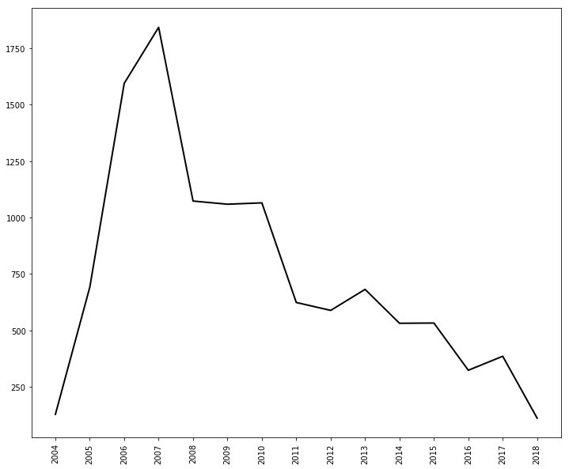

```python
cnt = collections.Counter(rev_years).items()
cnt = sorted(cnt, key=lambda x: x[0])
plt.xticks(rotation=90)
plt.plot([x[0] for x in cnt], [x[1] for x in cnt], 'k-', lw=2)
```

### Revision data

We now have some information about each of the page revisions, but we still have not seen how to grab the actual page data from a given revision. To do this, we need to return to the "parse" API with our revision ids in hand. Essentially, all we need to do is call the parse action, specify the format as JSON, and provid the revid to the parameter `oldid`. So, to get the very first version of the coffee page we would first get the revision id:

```python
revid = rev_data[-1]['revid']
revid
```

```
3245467
```

And then place the following API query:

```python
api_query = base_api_url + "action=parse&" + "format=json&" + \
            "oldid={0:d}&".format(revid)
r = requests.get(api_query)
page_data = r.json()['parse']
```

```python
page_data.keys()
```

```
dict_keys(['title', 'pageid', 'revid', 'text', 'langlinks', 'categories', 'links', 'templates', 'images', 'externallinks', 'sections', 'parsewarnings', 'displaytitle', 'iwlinks', 'properties'])
```

It would be fun to see what this page actually looks like rendered as html. Let's write it to disk with some header information to make it look reasonable:

```python
with open('temp.html', 'w', encoding="UTF-8") as fin:
    fin.writelines("<html><body>")
    fin.writelines(page_data['text']['*'])
    fin.writelines("</body></html>")
```

You should see that the page was very basic back in 2004!

### A different page

Repeat the code above (you can drop all of the steps into one or two code blocks) to look at another page that interests you.

```
Pulling data from MediaWiki API: 'Data Science'
Loaded 856 revisions, through 2012-04-11T17:34:10Z
```

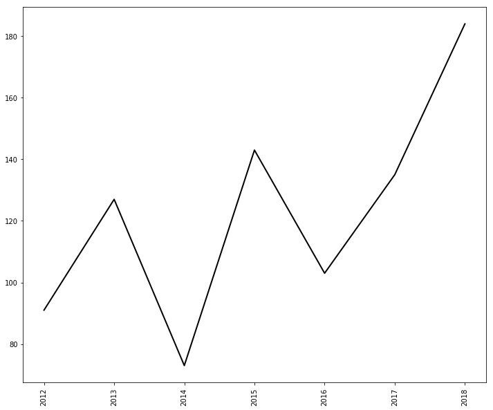

```python
rev_data = wiki_page_revisions("Data Science")
rev_years = []

for rev in rev_data:
    rev_years.append(rev['timestamp'][:4])

cnt = collections.Counter(rev_years).items()
cnt = sorted(cnt, key=lambda x: x[0])
plt.xticks(rotation=90)
plt.plot([x[0] for x in cnt], [x[1] for x in cnt], 'k-', lw=2)
```

How does the pattern of number of changes differ from the coffee page?

**Answer**:

### What next

We certainly could grab the revision history for every change that has been made to the Coffee page. Most changes, though, are not particularly interesting on their own (at least for our level of study here). Instead, I want to focus on large-scale change over time by grabbing one page for each year in the collection. Starting with the values in `rev_data`, I want you to use the space below to grab the last version of the pages on Coffee for each year. That is, start with the current page, then get the last page from 2017, then 2016, and so forth until you get back to the page at the end of 2004. Store these pages as a list named `page_history`.

```python
# Note: run this cell just once to refresh the value in `rev_data`
# from running the code to grab a different page above
rev_data = wiki_page_revisions("Coffee")
```

```
Loaded 1000 revisions, through 2015-10-06T08:23:46Z
Loaded 1500 revisions, through 2014-09-14T21:47:07Z
Loaded 2000 revisions, through 2013-10-27T19:56:47Z
Loaded 2500 revisions, through 2013-02-05T18:42:36Z
Loaded 3000 revisions, through 2012-03-22T05:58:50Z
Loaded 3500 revisions, through 2011-05-27T18:39:36Z
Loaded 4000 revisions, through 2010-09-17T23:47:21Z
Loaded 4500 revisions, through 2010-02-13T10:47:58Z
Loaded 5000 revisions, through 2009-12-04T23:59:54Z
Loaded 5500 revisions, through 2009-05-16T00:31:27Z
Loaded 6000 revisions, through 2008-12-06T00:40:05Z
Loaded 6500 revisions, through 2008-05-17T16:42:47Z
Loaded 7000 revisions, through 2007-12-19T01:21:52Z
Loaded 7500 revisions, through 2007-09-17T14:02:50Z
Loaded 8000 revisions, through 2007-06-12T21:59:14Z
Loaded 8500 revisions, through 2007-03-13T18:05:46Z
Loaded 9000 revisions, through 2006-11-21T17:23:22Z
Loaded 9500 revisions, through 2006-08-27T12:38:01Z
Loaded 10000 revisions, through 2006-04-11T18:00:27Z
Loaded 10500 revisions, through 2005-12-15T11:29:51Z
Loaded 11000 revisions, through 2005-05-09T23:33:14Z
Loaded 11236 revisions, through 2004-04-18T21:41:42Z
```

```python
base_api_url = 'https://' + lang + '.wikipedia.org/w/api.php?'

page_history = []
last_year = int(rev_data[0]['timestamp'][:4]) + 1

for rev in rev_data:
    this_year = int(rev['timestamp'][:4])
    if this_year < last_year:
        last_year = this_year

        # grab the page
        revid = rev['revid']
        api_query = base_api_url + "action=parse&" + "format=json&" + \
            "oldid={0:d}&".format(revid)
        r = requests.get(api_query)
        page_data = r.json()['parse']

        page_history.append((rev, page_data))

        # output progress
        print("Grabbed page at {0:d}".format(revid))
```

```
Grabbed page at 865835930
Grabbed page at 817267881
Grabbed page at 755468653
Grabbed page at 697272803
Grabbed page at 640191769
Grabbed page at 588559107
Grabbed page at 530615673
Grabbed page at 468752501
Grabbed page at 405119400
Grabbed page at 335170993
Grabbed page at 260942162
Grabbed page at 181074859
Grabbed page at 97628123
Grabbed page at 33382948
Grabbed page at 9036398
```

Then, when you are done with that, cycle through the pages to extract the length of the page in characters, the number of internal links, the number of external links, the number of images, and the number of sections.

```python
import xml.etree.ElementTree as ET
import pandas as pd

meta = dict(timestamp=[], pageid=[], revid=[], link=[], title=[], year=[],
            num_chars=[], num_p=[], num_sections=[], num_images=[], num_ilinks=[],
            num_elinks=[], num_langs=[])

for rev, page_data in page_history:
    tree = ET.fromstring(page_data['text']['*'])
    meta['timestamp'].append(rev['timestamp'])
    meta['pageid'].append(page_data['pageid'])
    meta['revid'].append(rev['revid'])
    meta['link'].append(re.sub(' ', '_', page_data['title']))
    meta['title'].append(re.sub('<[^>]+>', '', page_data['displaytitle']))
    meta['year'].append(int(rev['timestamp'][:4]))
    meta['num_chars'].append(len(page_data['text']['*']))
    meta['num_p'].append(len(tree.findall(".//p")))
    meta['num_sections'].append(len(page_data['sections']))
    meta['num_images'].append(len(page_data['images']))
    meta['num_ilinks'].append(len(page_data['links']))
    meta['num_elinks'].append(len(page_data['externallinks']))
    meta['num_langs'].append(len(page_data['langlinks']))


pdf = pd.DataFrame(meta).drop_duplicates()
pdf
```

|  | timestamp | pageid | revid | link | title | year | num_chars | num_p | num_sections | num_images | num_ilinks | num_elinks | num_langs |
| --- | --- | --- | --- | --- | --- | --- | --- | --- | --- | --- | --- | --- | --- |
| 0 | 2018-10-26T13:55:56Z | 604727 | 865835930 | Coffee | Coffee | 2018 | 448075 | 130 | 42 | 43 | 681 | 241 | 169 |
| 1 | 2017-12-27T07:58:07Z | 604727 | 817267881 | Coffee | Coffee | 2017 | 437723 | 128 | 40 | 47 | 660 | 231 | 169 |
| 2 | 2016-12-18T05:42:22Z | 604727 | 755468653 | Coffee | Coffee | 2016 | 459558 | 133 | 44 | 50 | 652 | 239 | 169 |
| 3 | 2015-12-29T11:13:18Z | 604727 | 697272803 | Coffee | Coffee | 2015 | 433789 | 126 | 42 | 44 | 644 | 198 | 169 |
| 4 | 2014-12-30T04:41:08Z | 604727 | 640191769 | Coffee | Coffee | 2014 | 421406 | 126 | 44 | 58 | 595 | 183 | 169 |
| 5 | 2013-12-31T18:54:37Z | 604727 | 588559107 | Coffee | Coffee | 2013 | 374642 | 129 | 43 | 56 | 556 | 140 | 169 |
| 6 | 2012-12-31T14:43:47Z | 604727 | 530615673 | Coffee | Coffee | 2012 | 360744 | 119 | 38 | 48 | 537 | 152 | 169 |
| 7 | 2011-12-31T10:26:36Z | 604727 | 468752501 | Coffee | Coffee | 2011 | 358617 | 114 | 33 | 54 | 536 | 151 | 169 |
| 8 | 2010-12-31T05:22:50Z | 604727 | 405119400 | Coffee | Coffee | 2010 | 328394 | 89 | 32 | 49 | 498 | 139 | 170 |
| 9 | 2009-12-31T20:57:40Z | 604727 | 335170993 | Coffee | Coffee | 2009 | 244457 | 65 | 23 | 46 | 391 | 103 | 170 |
| 10 | 2008-12-30T20:11:56Z | 604727 | 260942162 | Coffee | Coffee | 2008 | 194285 | 50 | 21 | 35 | 320 | 89 | 170 |
| 11 | 2007-12-30T23:01:42Z | 604727 | 181074859 | Coffee | Coffee | 2007 | 160272 | 39 | 16 | 18 | 299 | 68 | 169 |
| 12 | 2006-12-31T23:39:41Z | 604727 | 97628123 | Coffee | Coffee | 2006 | 95116 | 31 | 21 | 14 | 234 | 25 | 169 |
| 13 | 2005-12-31T15:36:40Z | 604727 | 33382948 | Coffee | Coffee | 2005 | 114129 | 79 | 39 | 18 | 298 | 34 | 169 |
| 14 | 2004-12-30T20:13:34Z | 604727 | 9036398 | Coffee | Coffee | 2004 | 33909 | 33 | 15 | 3 | 86 | 5 | 169 |

Finally, plot the data across time for each of these variables. For example, if you stored the data for the number of internal links as a list named `num_ilinks`, you should be able to run something like this:

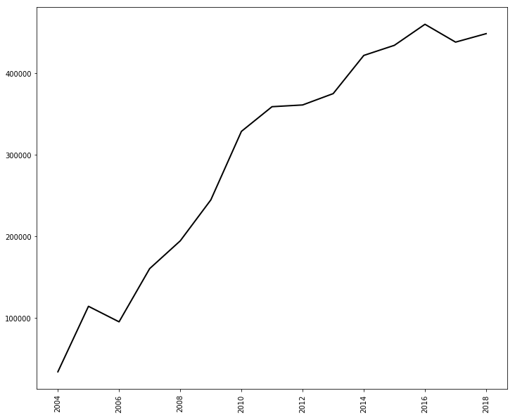

```python
plt.xticks(rotation=90)
plt.plot(list(range(2018,2003,-1)), pdf['num_chars'], 'k-', lw=2)
```

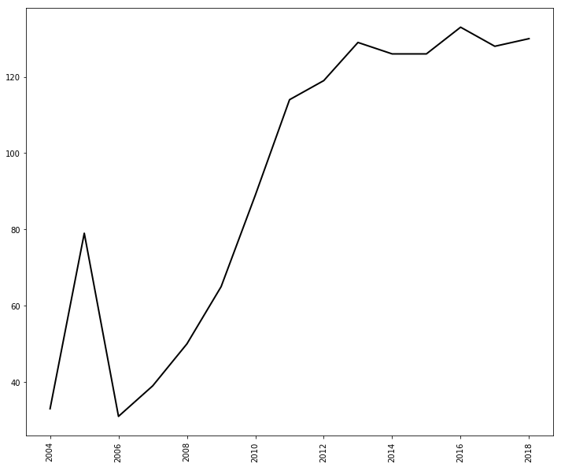

```python
plt.xticks(rotation=90)
plt.plot(list(range(2018,2003,-1)), pdf['num_p'], 'k-', lw=2)
```

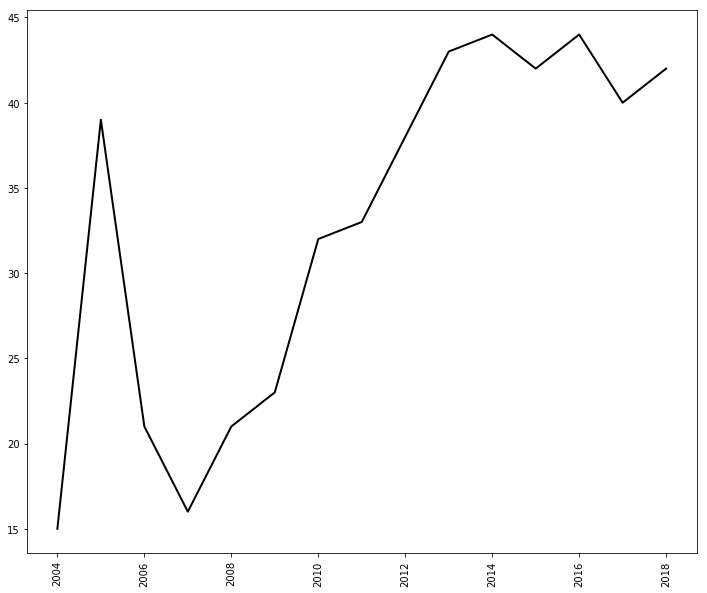

```python
plt.xticks(rotation=90)
plt.plot(list(range(2018,2003,-1)), pdf['num_sections'], 'k-', lw=2)
```

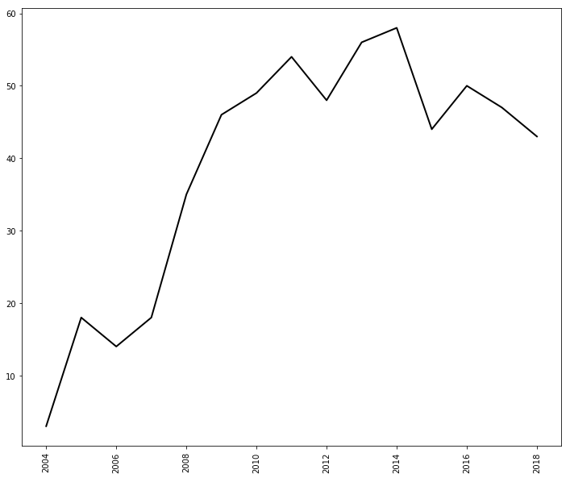

```python
plt.xticks(rotation=90)
plt.plot(list(range(2018,2003,-1)), pdf['num_images'], 'k-', lw=2)
```

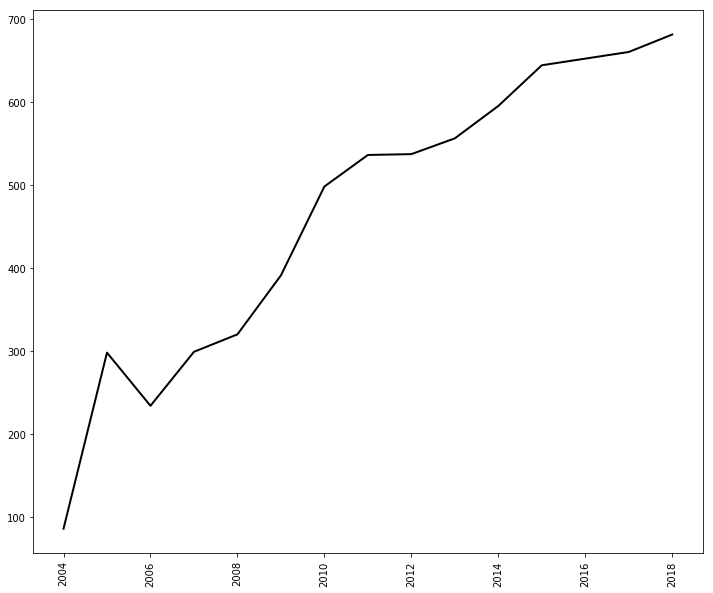

```python
plt.xticks(rotation=90)
plt.plot(list(range(2018,2003,-1)), pdf['num_ilinks'], 'k-', lw=2)
```

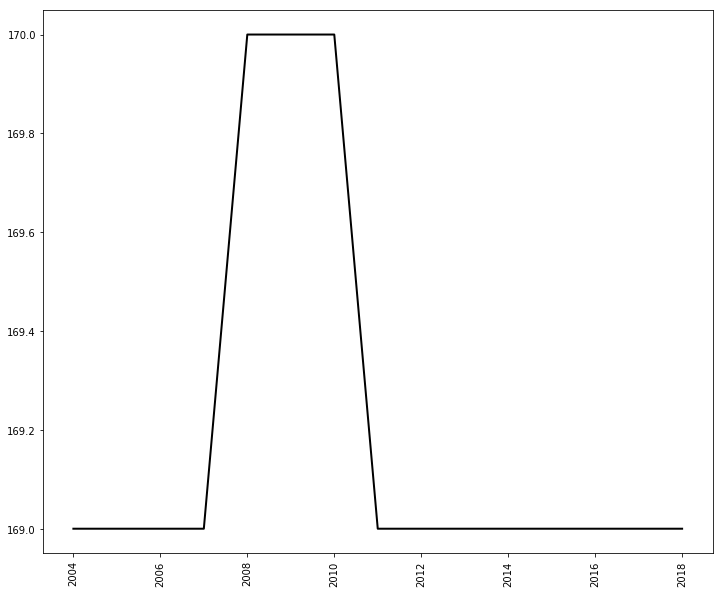

```python
plt.xticks(rotation=90)
plt.plot(list(range(2018,2003,-1)), pdf['num_langs'], 'k-', lw=2)
```

```python
plt.xticks(rotation=90)
plt.plot(list(range(2018,2003,-1)), pdf['num_elinks'], 'k-', lw=2)
```

[output not shown]

Take note of any interesting patterns that arise over time with the pages.

### Even more practice

My guess is that the above tasks will take up most of the class time. If you want extra practice or finish early, wrap up the code above in a function that takes just a page name and returns all of the metrics as a panda's DataFrame object. Include the timestamp as the first column of the data frame and make sure that you handle the case where the number of years may be different and there may even be no revisions in a given year.

```python
def get_page_history(page_title):

    rev_data = wiki_page_revisions(page_title)
    base_api_url = 'https://' + lang + '.wikipedia.org/w/api.php?'

    page_history = []
    last_year = int(rev_data[0]['timestamp'][:4]) + 1

    for rev in rev_data:
        this_year = int(rev['timestamp'][:4])
        if this_year < last_year:
            last_year = this_year

            # grab the page
            revid = rev['revid']
            api_query = base_api_url + "action=parse&" + "format=json&" + \
                "oldid={0:d}&".format(revid)
            r = requests.get(api_query)
            page_data = r.json()['parse']

            page_history.append((rev, page_data))

            # output progress
            print("Grabbed page at {0:d}".format(revid))

    return page_history
```

```python
def get_page_history_meta(page_title):
    import xml.etree.ElementTree as ET
    import pandas as pd

    page_history = get_page_history(page_title)

    meta = dict(timestamp=[], pageid=[], revid=[], link=[], title=[], year=[],
                num_chars=[], num_p=[], num_sections=[], num_images=[], num_ilinks=[],
                num_elinks=[], num_langs=[])

    for rev, page_data in page_history:
        tree = ET.fromstring(page_data['text']['*'])
        meta['timestamp'].append(rev['timestamp'])
        meta['pageid'].append(page_data['pageid'])
        meta['revid'].append(rev['revid'])
        meta['link'].append(re.sub(' ', '_', page_data['title']))
        meta['title'].append(re.sub('<[^>]+>', '', page_data['displaytitle']))
        meta['year'].append(int(rev['timestamp'][:4]))
        meta['num_chars'].append(len(page_data['text']['*']))
        meta['num_p'].append(len(tree.findall(".//p")))
        meta['num_sections'].append(len(page_data['sections']))
        meta['num_images'].append(len(page_data['images']))
        meta['num_ilinks'].append(len(page_data['links']))
        meta['num_elinks'].append(len(page_data['externallinks']))
        meta['num_langs'].append(len(page_data['langlinks']))

    pdf = pd.DataFrame(meta).drop_duplicates()
    return pdf
```

```python
pdf = get_page_history_meta('Statistics')
pdf
```

```
Loaded 1000 revisions, through 2013-04-30T23:42:38Z
Loaded 1500 revisions, through 2011-09-03T11:53:09Z
Loaded 2000 revisions, through 2010-04-25T19:30:12Z
Loaded 2500 revisions, through 2009-01-28T22:27:38Z
Loaded 3000 revisions, through 2008-04-07T23:47:45Z
Loaded 3500 revisions, through 2007-05-03T18:11:22Z
Loaded 4000 revisions, through 2006-05-25T16:59:29Z
Loaded 4500 revisions, through 2004-10-11T04:40:07Z
Loaded 4715 revisions, through 2001-02-22T11:02:15Z
Grabbed page at 867661767
Grabbed page at 817612155
Grabbed page at 754986487
Grabbed page at 697433595
Grabbed page at 639300278
Grabbed page at 588463335
Grabbed page at 530307227
Grabbed page at 468573297
Grabbed page at 403631349
Grabbed page at 334749989
Grabbed page at 260637347
Grabbed page at 181279972
Grabbed page at 97370751
Grabbed page at 33018695
Grabbed page at 9191083
Grabbed page at 2220137
Grabbed page at 556462
Grabbed page at 279816
```

|  | timestamp | pageid | revid | link | title | year | num_chars | num_p | num_sections | num_images | num_ilinks | num_elinks | num_langs |
| --- | --- | --- | --- | --- | --- | --- | --- | --- | --- | --- | --- | --- | --- |
| 0 | 2018-11-07T05:14:26Z | 26685 | 867661767 | Statistics | Statistics | 2018 | 240263 | 69 | 30 | 23 | 642 | 54 | 131 |
| 1 | 2017-12-29T14:02:01Z | 26685 | 817612155 | Statistics | Statistics | 2017 | 217251 | 71 | 30 | 16 | 575 | 47 | 131 |
| 2 | 2016-12-15T16:32:00Z | 26685 | 754986487 | Statistics | Statistics | 2016 | 220733 | 69 | 30 | 25 | 578 | 43 | 131 |
| 3 | 2015-12-30T14:08:50Z | 26685 | 697433595 | Statistics | Statistics | 2015 | 213930 | 68 | 30 | 24 | 574 | 38 | 131 |
| 4 | 2014-12-23T07:13:33Z | 26685 | 639300278 | Statistics | Statistics | 2014 | 191070 | 67 | 28 | 24 | 547 | 17 | 131 |
| 5 | 2013-12-31T02:50:14Z | 26685 | 588463335 | Statistics | Statistics | 2013 | 165371 | 53 | 20 | 18 | 528 | 20 | 131 |
| 6 | 2012-12-29T15:29:36Z | 26685 | 530307227 | Statistics | Statistics | 2012 | 153761 | 49 | 20 | 15 | 514 | 12 | 131 |
| 7 | 2011-12-30T10:17:04Z | 26685 | 468573297 | Statistics | Statistics | 2011 | 149561 | 47 | 24 | 14 | 506 | 22 | 131 |
| 8 | 2010-12-22T01:49:03Z | 26685 | 403631349 | Statistics | Statistics | 2010 | 145910 | 46 | 24 | 15 | 501 | 22 | 131 |
| 9 | 2009-12-29T17:08:16Z | 26685 | 334749989 | Statistics | Statistics | 2009 | 140638 | 49 | 24 | 14 | 490 | 23 | 131 |
| 10 | 2008-12-29T07:58:39Z | 26685 | 260637347 | Statistics | Statistics | 2008 | 124992 | 36 | 16 | 15 | 488 | 13 | 131 |
| 11 | 2007-12-31T22:52:04Z | 26685 | 181279972 | Statistics | Statistics | 2007 | 137766 | 49 | 20 | 9 | 539 | 39 | 131 |
| 12 | 2006-12-30T18:06:41Z | 26685 | 97370751 | Statistics | Statistics | 2006 | 68782 | 47 | 21 | 3 | 214 | 27 | 131 |
| 13 | 2005-12-28T18:16:20Z | 26685 | 33018695 | Statistics | Statistics | 2005 | 52753 | 25 | 17 | 6 | 182 | 45 | 131 |
| 14 | 2004-12-31T01:51:03Z | 26685 | 9191083 | Statistics | Statistics | 2004 | 19079 | 18 | 8 | 0 | 69 | 18 | 131 |
| 15 | 2003-12-31T18:44:55Z | 26685 | 2220137 | Statistics | Statistics | 2003 | 9822 | 12 | 3 | 0 | 53 | 3 | 131 |
| 16 | 2002-12-28T08:47:09Z | 26685 | 556462 | Statistics | Statistics | 2002 | 2743 | 4 | 2 | 0 | 12 | 1 | 131 |
| 17 | 2001-11-03T02:49:39Z | 26685 | 279816 | Statistics | Statistics | 2001 | 3055 | 12 | 0 | 0 | 10 | 0 | 131 |